# Assessment 1

Heeral s4653155

2022-03-03

# RMarkdown editing

*Interactive documents* are a new way to build Shiny apps. An interactive document is an **R Markdown** file that contains Shiny widgets and outputs. You write the report in markdown, and then launch it as an app with the click of a button. **R Markdown** is a file format for making dynamic documents with R. An **R Markdown** document is written in markdown (an easy-to-write plain text format) and contains chunks of embedded R code. To know more [Click here](https://rmarkdown.rstudio.com/lesson-8.htm)

Creating a new variable named “fastfood” with the dataset.

```r
#install.packages("tidyverse")
library(tidyverse)
fastfood <- read.csv("https://raw.githubusercontent.com/rfordatascience/tidytuesday/master/data/2018/2018-09-04/fastfood_calories.csv")
```

### Displaying the first 10 rows of the dataset using head()

```r
head(fastfood,10)
```

```
##     X restaurant                                      item calories cal_fat
## 1   1  Mcdonalds          Artisan Grilled Chicken Sandwich      380      60
## 2   2  Mcdonalds            Single Bacon Smokehouse Burger      840     410
## 3   3  Mcdonalds            Double Bacon Smokehouse Burger     1130     600
## 4   4  Mcdonalds Grilled Bacon Smokehouse Chicken Sandwich      750     280
## 5   5  Mcdonalds  Crispy Bacon Smokehouse Chicken Sandwich      920     410
## 6   6  Mcdonalds                                   Big Mac      540     250
## 7   7  Mcdonalds                              Cheeseburger      300     100
## 8   8  Mcdonalds                  Classic Chicken Sandwich      510     210
## 9   9  Mcdonalds                       Double Cheeseburger      430     190
## 10 10  Mcdonalds      Double Quarter PounderÂ® with Cheese      770     400
##    total_fat sat_fat trans_fat cholesterol sodium total_carb fiber sugar
## 1          7       2       0.0          95   1110         44     3    11
## 2         45      17       1.5         130   1580         62     2    18
## 3         67      27       3.0         220   1920         63     3    18
```

[output cut: 18 more lines]

### Displaying the first 10 rows of the dataset using kable()

```r
#install.packages("knitr")
library(knitr)

kable(fastfood[1:10,])
```

| X | restaurant | item | calories | cal_fat | total_fat | sat_fat | trans_fat | cholesterol | sodium | total_carb | fiber | sugar | protein | vit_a | vit_c | calcium | salad |
| --- | --- | --- | --- | --- | --- | --- | --- | --- | --- | --- | --- | --- | --- | --- | --- | --- | --- |
| 1 | Mcdonalds | Artisan Grilled Chicken Sandwich | 380 | 60 | 7 | 2 | 0.0 | 95 | 1110 | 44 | 3 | 11 | 37 | 4 | 20 | 20 | Other |
| 2 | Mcdonalds | Single Bacon Smokehouse Burger | 840 | 410 | 45 | 17 | 1.5 | 130 | 1580 | 62 | 2 | 18 | 46 | 6 | 20 | 20 | Other |
| 3 | Mcdonalds | Double Bacon Smokehouse Burger | 1130 | 600 | 67 | 27 | 3.0 | 220 | 1920 | 63 | 3 | 18 | 70 | 10 | 20 | 50 | Other |
| 4 | Mcdonalds | Grilled Bacon Smokehouse Chicken Sandwich | 750 | 280 | 31 | 10 | 0.5 | 155 | 1940 | 62 | 2 | 18 | 55 | 6 | 25 | 20 | Other |
| 5 | Mcdonalds | Crispy Bacon Smokehouse Chicken Sandwich | 920 | 410 | 45 | 12 | 0.5 | 120 | 1980 | 81 | 4 | 18 | 46 | 6 | 20 | 20 | Other |
| 6 | Mcdonalds | Big Mac | 540 | 250 | 28 | 10 | 1.0 | 80 | 950 | 46 | 3 | 9 | 25 | 10 | 2 | 15 | Other |
| 7 | Mcdonalds | Cheeseburger | 300 | 100 | 12 | 5 | 0.5 | 40 | 680 | 33 | 2 | 7 | 15 | 10 | 2 | 10 | Other |
| 8 | Mcdonalds | Classic Chicken Sandwich | 510 | 210 | 24 | 4 | 0.0 | 65 | 1040 | 49 | 3 | 6 | 25 | 0 | 4 | 2 | Other |
| 9 | Mcdonalds | Double Cheeseburger | 430 | 190 | 21 | 11 | 1.0 | 85 | 1040 | 35 | 2 | 7 | 25 | 20 | 4 | 15 | Other |
| 10 | Mcdonalds | Double Quarter PounderÂ® with Cheese | 770 | 400 | 45 | 21 | 2.5 | 175 | 1290 | 42 | 3 | 10 | 51 | 20 | 6 | 20 | Other |

### Displaying the first 10 rows of the dataset and the first 5 variables

```r
kable(fastfood[1:10,1:5])
```

| X | restaurant | item | calories | cal_fat |
| --- | --- | --- | --- | --- |
| 1 | Mcdonalds | Artisan Grilled Chicken Sandwich | 380 | 60 |
| 2 | Mcdonalds | Single Bacon Smokehouse Burger | 840 | 410 |
| 3 | Mcdonalds | Double Bacon Smokehouse Burger | 1130 | 600 |
| 4 | Mcdonalds | Grilled Bacon Smokehouse Chicken Sandwich | 750 | 280 |
| 5 | Mcdonalds | Crispy Bacon Smokehouse Chicken Sandwich | 920 | 410 |
| 6 | Mcdonalds | Big Mac | 540 | 250 |
| 7 | Mcdonalds | Cheeseburger | 300 | 100 |
| 8 | Mcdonalds | Classic Chicken Sandwich | 510 | 210 |
| 9 | Mcdonalds | Double Cheeseburger | 430 | 190 |
| 10 | Mcdonalds | Double Quarter PounderÂ® with Cheese | 770 | 400 |

(Part 2)

### Displaying food Items (observations) with more than 1000 calories

```r
fastfood %>%
  filter(calories>1000)
```

```
##      X  restaurant                                             item calories
## 1    3   Mcdonalds                   Double Bacon Smokehouse Burger     1130
## 2   38   Mcdonalds       10 piece Buttermilk Crispy Chicken Tenders     1210
## 3   39   Mcdonalds       12 piece Buttermilk Crispy Chicken Tenders     1510
## 4   40   Mcdonalds       20 piece Buttermilk Crispy Chicken Tenders     2430
## 5   45   Mcdonalds                       40 piece Chicken McNuggets     1770
## 6   48   Mcdonalds 10 piece Sweet N' Spicy Honey BBQ Glazed Tenders     1600
## 7   99       Sonic   Super Sonic Bacon Double Cheeseburger (w/mayo)     1280
## 8  100       Sonic       Super Sonic Double Cheeseburger W/ Mustard     1120
## 9  101       Sonic       Super Sonic Double Cheeseburger W/ Ketchup     1130
## 10 102       Sonic          Super Sonic Double Cheeseburger W/ Mayo     1220
## 11 103       Sonic         Super Sonic Jalapeno Double Cheeseburger     1120
## 12 116       Sonic Garlic Parmesan Dunked Ultimate Chicken Sandwich     1350
## 13 122       Sonic        4 Piece Super Crunch Chicken Strip Dinner     1080
## 14 123       Sonic        5 Piece Super Crunch Chicken Strip Dinner     1190
```

[output cut: 72 more lines]

### Don’t eat this

Saving a new variable (dataset) called `dont_eat_this’ showing observations with more than 40 in total_fat and more than 80 in total_carb in the descending order

```r
dont_eat_this <- fastfood %>%
  filter(total_fat>40 & total_carb>80) %>%
  arrange(desc(total_carb))

kable(dont_eat_this)
```

| X | restaurant | item | calories | cal_fat | total_fat | sat_fat | trans_fat | cholesterol | sodium | total_carb | fiber | sugar | protein | vit_a | vit_c | calcium | salad |
| --- | --- | --- | --- | --- | --- | --- | --- | --- | --- | --- | --- | --- | --- | --- | --- | --- | --- |
| 48 | Mcdonalds | 10 piece Sweet N’ Spicy Honey BBQ Glazed Tenders | 1600 | 600 | 66 | 10 | 0.0 | 265 | 4450 | 156 | 5 | 87 | 97 | 8 | 40 | 10 | Other |
| 123 | Sonic | 5 Piece Super Crunch Chicken Strip Dinner | 1190 | 510 | 57 | 10 | 1.0 | 90 | 2610 | 126 | 8 | 9 | 44 | 2 | 8 | 14 | Other |
| 271 | Dairy Queen | 6 Piece Chicken Strip Basket w/ Country Gravy | 1260 | 590 | 66 | 11 | 1.0 | 120 | 3500 | 121 | 12 | 4 | 49 | 2 | 0 | 10 | Other |
| 122 | Sonic | 4 Piece Super Crunch Chicken Strip Dinner | 1080 | 460 | 51 | 9 | 1.0 | 75 | 2390 | 118 | 8 | 9 | 37 | 1 | 7 | 13 | Other |
| 121 | Sonic | 3 Piece Super Crunch Chicken Strip Dinner | 970 | 410 | 46 | 8 | 1.0 | 55 | 2160 | 109 | 7 | 9 | 30 | 1 | 6 | 13 | Other |
| 45 | Mcdonalds | 40 piece Chicken McNuggets | 1770 | 960 | 107 | 18 | 0.5 | 295 | 3370 | 105 | 7 | 1 | 98 | 0 | 15 | 6 | Other |
| 270 | Dairy Queen | 4 Piece Chicken Strip Basket w/ Country Gravy | 1030 | 480 | 53 | 9 | 1.0 | 80 | 2780 | 105 | 9 | 4 | 35 | 2 | 0 | 10 | Other |
| 40 | Mcdonalds | 20 piece Buttermilk Crispy Chicken Tenders | 2430 | 1270 | 141 | 24 | 2.0 | 475 | 6080 | 103 | 2 | 3 | 186 | 0 | 2 | 8 | Other |
| 291 | Dairy Queen | Steak Finger Basket | 910 | 430 | 48 | 13 | 0.5 | 45 | 2210 | 95 | 5 | 2 | 23 | NA | NA | NA | Other |
| 310 | Subway | Footlong Big Hot Pastrami | 1160 | 620 | 62 | 22 | 0.0 | 170 | 2940 | 94 | 10 | 14 | 58 | 20 | 90 | 80 | Other |
| 321 | Subway | Footlong Chicken & Bacon Ranch Melt | 1140 | 500 | 56 | 20 | 2.0 | 190 | 2160 | 94 | 10 | 16 | 70 | 30 | 50 | 100 | Other |
| 331 | Subway | Footlong Italian Hero | 1100 | 520 | 58 | 20 | 0.0 | 150 | 2940 | 94 | 10 | 18 | 52 | 20 | 40 | 80 | Other |
| 363 | Subway | Footlong Turkey Italiano Melt (with Provolone) | 980 | 420 | 48 | 18 | 2.0 | 100 | 2960 | 94 | 10 | 16 | 48 | 20 | 40 | 90 | Other |
| 431 | Taco Bell | XXL Grilled Stuft Burrito - Beef | 880 | 380 | 42 | 14 | 1.0 | 75 | 2020 | 94 | 12 | 6 | 31 | NA | NA | NA | Other |
| 319 | Subway | Footlong Carved Turkey & Bacon w/ Cheese | 1140 | 460 | 52 | 14 | 0.0 | 140 | 3200 | 92 | 10 | 16 | 66 | 20 | 40 | 80 | Other |
| 342 | Subway | Footlong Spicy Italian | 960 | 440 | 48 | 18 | 2.0 | 100 | 3040 | 92 | 10 | 16 | 40 | 16 | 40 | 60 | Other |
| 354 | Subway | Footlong Tuna | 940 | 420 | 48 | 8 | 0.0 | 60 | 1240 | 88 | 10 | 12 | 40 | 16 | 40 | 60 | Other |
| 176 | Arbys | Triple Decker Sandwich | 1030 | 459 | 51 | 17 | 1.0 | 155 | 2940 | 83 | 5 | 19 | 62 | NA | NA | NA | Other |
| 5 | Mcdonalds | Crispy Bacon Smokehouse Chicken Sandwich | 920 | 410 | 45 | 12 | 0.5 | 120 | 1980 | 81 | 4 | 18 | 46 | 6 | 20 | 20 | Other |
| 161 | Arbys | Pecan Chicken Salad Sandwich | 840 | 400 | 44 | 6 | 0.5 | 75 | 1210 | 81 | 6 | 20 | 33 | 10 | 8 | 25 | Other |

### Categorising food items

Creating a a new variable heavy_food using case_when() Showing details of food items which are heavy (>500 calories), low (<250 calories) and average (between 250 to 500 calories) and counting the observations in each category.

```r
fastfood <- fastfood %>%
  mutate(heavy_food = case_when(calories >= 500 ~ "heavy", calories < 250 ~ "low", T ~ "average"))

kable (fastfood)
```

| X | restaurant | item | calories | cal_fat | total_fat | sat_fat | trans_fat | cholesterol | sodium | total_carb | fiber | sugar | protein | vit_a | vit_c | calcium | salad | heavy_food |
| --- | --- | --- | --- | --- | --- | --- | --- | --- | --- | --- | --- | --- | --- | --- | --- | --- | --- | --- |
| 1 | Mcdonalds | Artisan Grilled Chicken Sandwich | 380 | 60 | 7 | 2.0 | 0.0 | 95 | 1110 | 44 | 3 | 11 | 37 | 4 | 20 | 20 | Other | average |
| 2 | Mcdonalds | Single Bacon Smokehouse Burger | 840 | 410 | 45 | 17.0 | 1.5 | 130 | 1580 | 62 | 2 | 18 | 46 | 6 | 20 | 20 | Other | heavy |
| 3 | Mcdonalds | Double Bacon Smokehouse Burger | 1130 | 600 | 67 | 27.0 | 3.0 | 220 | 1920 | 63 | 3 | 18 | 70 | 10 | 20 | 50 | Other | heavy |
| 4 | Mcdonalds | Grilled Bacon Smokehouse Chicken Sandwich | 750 | 280 | 31 | 10.0 | 0.5 | 155 | 1940 | 62 | 2 | 18 | 55 | 6 | 25 | 20 | Other | heavy |
| 5 | Mcdonalds | Crispy Bacon Smokehouse Chicken Sandwich | 920 | 410 | 45 | 12.0 | 0.5 | 120 | 1980 | 81 | 4 | 18 | 46 | 6 | 20 | 20 | Other | heavy |
| 6 | Mcdonalds | Big Mac | 540 | 250 | 28 | 10.0 | 1.0 | 80 | 950 | 46 | 3 | 9 | 25 | 10 | 2 | 15 | Other | heavy |
| 7 | Mcdonalds | Cheeseburger | 300 | 100 | 12 | 5.0 | 0.5 | 40 | 680 | 33 | 2 | 7 | 15 | 10 | 2 | 10 | Other | average |
| 8 | Mcdonalds | Classic Chicken Sandwich | 510 | 210 | 24 | 4.0 | 0.0 | 65 | 1040 | 49 | 3 | 6 | 25 | 0 | 4 | 2 | Other | heavy |
| 9 | Mcdonalds | Double Cheeseburger | 430 | 190 | 21 | 11.0 | 1.0 | 85 | 1040 | 35 | 2 | 7 | 25 | 20 | 4 | 15 | Other | average |
| 10 | Mcdonalds | Double Quarter Pounder® with Cheese | 770 | 400 | 45 | 21.0 | 2.5 | 175 | 1290 | 42 | 3 | 10 | 51 | 20 | 6 | 20 | Other | heavy |
| 11 | Mcdonalds | Filet-O-Fish® | 380 | 170 | 18 | 4.0 | 0.0 | 40 | 640 | 38 | 2 | 5 | 15 | 2 | 0 | 15 | Other | average |
| 12 | Mcdonalds | Garlic White Cheddar Burger | 620 | 300 | 34 | 13.0 | 1.5 | 95 | 790 | 48 | 3 | 11 | 32 | 10 | 10 | 35 | Other | heavy |
| 13 | Mcdonalds | Grilled Garlic White Cheddar Chicken Sandwich | 530 | 180 | 20 | 7.0 | 0.0 | 125 | 1150 | 48 | 3 | 11 | 42 | 10 | 20 | 35 | Other | heavy |
| 14 | Mcdonalds | Crispy Garlic White Cheddar Chicken Sandwich | 700 | 300 | 34 | 9.0 | 0.0 | 85 | 1190 | 67 | 5 | 11 | 33 | 10 | 15 | 35 | Other | heavy |
| 15 | Mcdonalds | Hamburger | 250 | 70 | 8 | 3.0 | 0.0 | 30 | 480 | 31 | 2 | 6 | 13 | 2 | 2 | 4 | Other | average |
| 16 | Mcdonalds | Lobster Roll | 290 | 50 | 5 | 1.5 | 0.0 | 65 | 630 | 35 | 2 | 3 | 24 | 4 | 6 | 15 | Other | average |
| 17 | Mcdonalds | Maple Bacon Dijon 1/4 lb Burger | 640 | 330 | 36 | 14.0 | 1.5 | 110 | 1260 | 40 | 3 | 10 | 37 | 6 | 15 | 15 | Other | heavy |
| 18 | Mcdonalds | Grilled Maple Bacon Dijon Chicken Sandwich | 580 | 190 | 21 | 8.0 | 0.0 | 135 | 1890 | 50 | 3 | 14 | 48 | 4 | 30 | 30 | Other | heavy |
| 19 | Mcdonalds | Crispy Maple Bacon Dijon Chicken Sandwich | 740 | 310 | 35 | 9.0 | 0.5 | 95 | 1780 | 69 | 5 | 14 | 39 | 4 | 20 | 290 | Other | heavy |
| 20 | Mcdonalds | McChicken | 350 | 130 | 15 | 3.5 | 0.0 | 40 | 600 | 40 | 2 | 5 | 15 | 2 | 2 | 4 | Other | average |
| 21 | Mcdonalds | McDouble | 380 | 160 | 18 | 8.0 | 1.0 | 70 | 840 | 34 | 2 | 7 | 23 | 10 | 2 | 10 | Other | average |
| 22 | Mcdonalds | McRib | 480 | 200 | 22 | 7.0 | 0.0 | 80 | 870 | 45 | 2 | 12 | 25 | 2 | 2 | 6 | Other | average |
| 23 | Mcdonalds | Pico Guacamole 1/4 lb Burger | 580 | 300 | 33 | 12.0 | 1.5 | 95 | 920 | 41 | 4 | 7 | 29 | 8 | 15 | 15 | Other | heavy |
| 24 | Mcdonalds | Grilled Pico Guacamole Chicken Sandwich | 520 | 160 | 18 | 6.0 | 0.0 | 115 | 1540 | 50 | 4 | 12 | 40 | 8 | 25 | 30 | Other | heavy |
| 25 | Mcdonalds | Crispy Pico Guacamole Chicken Sandwich | 680 | 280 | 32 | 7.0 | 0.0 | 80 | 1430 | 69 | 6 | 12 | 31 | 8 | 15 | 30 | Other | heavy |
| 26 | Mcdonalds | Premium Buttermilk Crispy Chicken Deluxe Sandwich | 570 | 200 | 23 | 5.0 | 0.0 | 60 | 1050 | 64 | 4 | 11 | 28 | 4 | 10 | 20 | Other | heavy |
| 27 | Mcdonalds | Premium Crispy Chicken Deluxe Sandwich | 530 | 200 | 22 | 4.0 | 0.0 | 45 | 1000 | 59 | 3 | 13 | 25 | 6 | 10 | 20 | Other | heavy |
| 28 | Mcdonalds | Quarter Pounder® with Cheese | 530 | 240 | 27 | 13.0 | 1.5 | 100 | 1090 | 41 | 3 | 10 | 31 | 20 | 6 | 15 | Other | heavy |
| 29 | Mcdonalds | Signature Sriracha Burger | 670 | 320 | 35 | 12.0 | 1.5 | 95 | 1010 | 56 | 4 | 13 | 32 | 20 | 15 | 30 | Other | heavy |
| 30 | Mcdonalds | Grilled Signature Sriracha Chicken Sandwich | 560 | 180 | 20 | 5.0 | 0.0 | 115 | 1550 | 56 | 4 | 14 | 41 | 20 | 25 | 30 | Other | heavy |

[output cut: 485 more lines]

```r
fastfood %>%
  count(heavy_food)
```

```
##   heavy_food   n
## 1    average 196
## 2      heavy 251
## 3        low  68
```

### Different types of variables

Displaying the types of variables in the dataset using `skimr` package.

```r
#install.packages("skimr")
library(skimr)

fastfood %>% skim()
```

Data summary

| Name | Piped data |
| --- | --- |
| Number of rows | 515 |
| Number of columns | 19 |
| _______________________ |  |
| Column type frequency: |  |
| character | 4 |
| numeric | 15 |
| ________________________ |  |
| Group variables | None |

**Variable type: character**

| skim_variable | n_missing | complete_rate | min | max | empty | n_unique | whitespace |
| --- | --- | --- | --- | --- | --- | --- | --- |
| restaurant | 0 | 1 | 5 | 11 | 0 | 8 | 0 |
| item | 0 | 1 | 5 | 63 | 0 | 505 | 0 |
| salad | 0 | 1 | 5 | 5 | 0 | 1 | 0 |
| heavy_food | 0 | 1 | 3 | 7 | 0 | 3 | 0 |

**Variable type: numeric**

| skim_variable | n_missing | complete_rate | mean | sd | p0 | p25 | p50 | p75 | p100 | hist |
| --- | --- | --- | --- | --- | --- | --- | --- | --- | --- | --- |
| X | 0 | 1.00 | 258.00 | 148.81 | 1 | 129.5 | 258.0 | 386.5 | 515 | ▇▇▇▇▇ |
| calories | 0 | 1.00 | 530.91 | 282.44 | 20 | 330.0 | 490.0 | 690.0 | 2430 | ▇▆▁▁▁ |
| cal_fat | 0 | 1.00 | 238.81 | 166.41 | 0 | 120.0 | 210.0 | 310.0 | 1270 | ▇▃▁▁▁ |
| total_fat | 0 | 1.00 | 26.59 | 18.41 | 0 | 14.0 | 23.0 | 35.0 | 141 | ▇▃▁▁▁ |
| sat_fat | 0 | 1.00 | 8.15 | 6.42 | 0 | 4.0 | 7.0 | 11.0 | 47 | ▇▃▁▁▁ |
| trans_fat | 0 | 1.00 | 0.47 | 0.84 | 0 | 0.0 | 0.0 | 1.0 | 8 | ▇▁▁▁▁ |
| cholesterol | 0 | 1.00 | 72.46 | 63.16 | 0 | 35.0 | 60.0 | 95.0 | 805 | ▇▁▁▁▁ |
| sodium | 0 | 1.00 | 1246.74 | 689.95 | 15 | 800.0 | 1110.0 | 1550.0 | 6080 | ▇▆▁▁▁ |
| total_carb | 0 | 1.00 | 45.66 | 24.88 | 0 | 28.5 | 44.0 | 57.0 | 156 | ▅▇▂▁▁ |
| fiber | 12 | 0.98 | 4.14 | 3.04 | 0 | 2.0 | 3.0 | 5.0 | 17 | ▇▅▂▁▁ |
| sugar | 0 | 1.00 | 7.26 | 6.76 | 0 | 3.0 | 6.0 | 9.0 | 87 | ▇▁▁▁▁ |
| protein | 1 | 1.00 | 27.89 | 17.68 | 1 | 16.0 | 24.5 | 36.0 | 186 | ▇▂▁▁▁ |
| vit_a | 214 | 0.58 | 18.86 | 31.38 | 0 | 4.0 | 10.0 | 20.0 | 180 | ▇▁▁▁▁ |
| vit_c | 210 | 0.59 | 20.17 | 30.59 | 0 | 4.0 | 10.0 | 30.0 | 400 | ▇▁▁▁▁ |
| calcium | 210 | 0.59 | 24.85 | 25.52 | 0 | 8.0 | 20.0 | 30.0 | 290 | ▇▁▁▁▁ |

### Number of dishes from each restaurant

Presenting the count observations from each restaurant in a descending order

```r
fastfood %>%
  count(restaurant, sort=TRUE)
```

```
##    restaurant   n
## 1   Taco Bell 115
## 2      Subway  96
## 3 Burger King  70
## 4   Mcdonalds  57
## 5       Arbys  55
## 6       Sonic  53
## 7 Dairy Queen  42
## 8 Chick Fil-A  27
```

### Items in the menu

```r
fastfood %>%
  count(item)
```

```
##                                                                item n
## 1                                            1 Piece Chick-n-Strips 1
## 2                                1/2 lb. FlameThrowerÂ® GrillBurger 1
## 3                                   1/2 lb. GrillBurger with Cheese 1
## 4                                    1/2 lb.* Cheesy Potato Burrito 1
## 5                                            1/2 lb.* Combo Burrito 1
## 6                                  1/4 lb. Bacon Cheese GrillBurger 1
## 7                                   1/4 lb. GrillBurger with Cheese 1
## 8                                1/4 lb. Mushroom Swiss GrillBurger 1
## 9                        10 piece Buttermilk Crispy Chicken Tenders 1
## 10                                       10 Piece Chicken McNuggets 1
## 11                 10 piece Sweet N' Spicy Honey BBQ Glazed Tenders 1
## 12                       12 piece Buttermilk Crispy Chicken Tenders 1
## 13                                         12 piece Chicken Nuggets 1
## 14                                 12 Piece Grilled Chicken Nuggets 1
```

[output cut: 491 more lines]

### Average calories for each restaurant

Using groupings (group_by()), summarising and displaying the average number of calories for each restaurant.

```r
fastfood %>%
  group_by(restaurant) %>%
  summarise(mean_calories = mean(calories)) %>%
  ungroup()
```

```
## # A tibble: 8 x 2
##   restaurant  mean_calories
##   <chr>               <dbl>
## 1 Arbys                533.
## 2 Burger King          609.
## 3 Chick Fil-A          384.
## 4 Dairy Queen          520.
## 5 Mcdonalds            640.
## 6 Sonic                632.
## 7 Subway               503.
## 8 Taco Bell            444.
```

### Calories_details

Displaying average calories per restaurant as “average_calories”

```r
Calories_details <- fastfood %>%
  group_by(restaurant) %>%
  mutate(average_calories = mean(calories))%>%
  summarise(average_calories = mean(calories))%>%
  ungroup()

kable(Calories_details)
```

| restaurant | average_calories |
| --- | --- |
| Arbys | 532.7273 |
| Burger King | 608.5714 |
| Chick Fil-A | 384.4444 |
| Dairy Queen | 520.2381 |
| Mcdonalds | 640.3509 |
| Sonic | 631.6981 |
| Subway | 503.0208 |
| Taco Bell | 443.6522 |

### Fat_details

Displaying maximum total_fat per restaurant as “max_fat”

```r
Fat_details <- fastfood %>%
  group_by(restaurant) %>%
  mutate(max_fat = max (total_fat)) %>%
  summarise(max_fat = max (total_fat)) %>%
  ungroup()

kable(Fat_details)
```

| restaurant | max_fat |
| --- | --- |
| Arbys | 59 |
| Burger King | 126 |
| Chick Fil-A | 47 |
| Dairy Queen | 75 |
| Mcdonalds | 141 |
| Sonic | 100 |
| Subway | 62 |
| Taco Bell | 42 |

### Cholesterol_details

Displaying minimum cholesterol per restaurant as “min_cholesterol”

```r
Cholestrol_details <- fastfood %>%
  group_by(restaurant) %>%
  mutate(min_cholesterol = min (cholesterol)) %>%
  summarise(min_cholesterol = min (cholesterol)) %>%
  ungroup()

kable(Cholestrol_details)
```

| restaurant | min_cholesterol |
| --- | --- |
| Arbys | 15 |
| Burger King | 5 |
| Chick Fil-A | 25 |
| Dairy Queen | 0 |
| Mcdonalds | 0 |
| Sonic | 0 |
| Subway | 0 |
| Taco Bell | 0 |

### Proportion of total fat

There is a certain amount of fat in all the food items from different restaurants. The below given bar graph helps us to indentify which restaurant provides food with less fat as compared to another restaurant. On x axis we have different restaurants while on y axis we have total fat proportion. Through the bar graph we can easily identify that among all the restaurants, the food items of Burger King has the most fat while that of Chick Fil-A has the least fat. Having food with more fat especially when we have a sedentary lifestyle is harmful to our health.

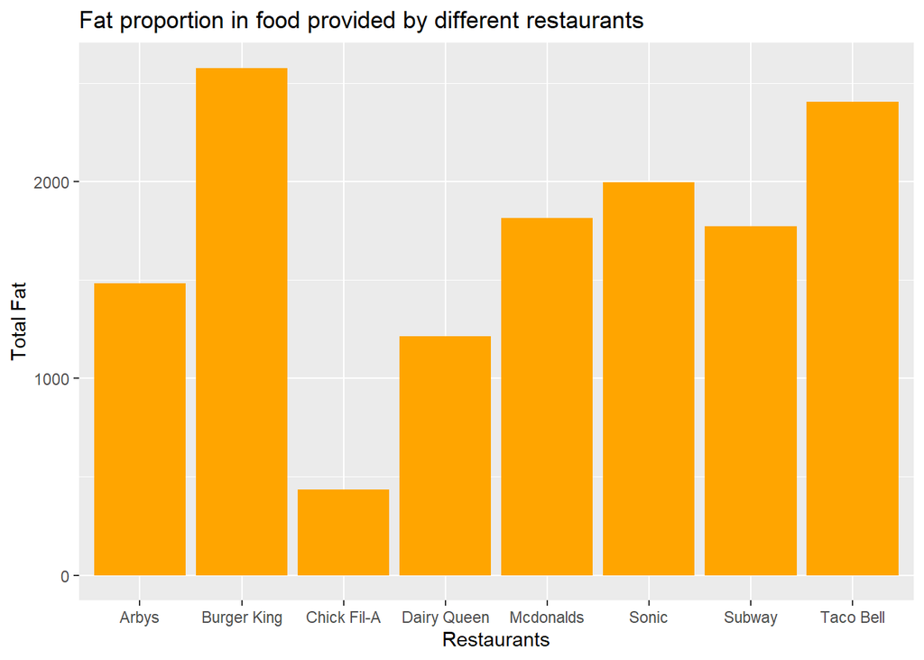

```r
fastfood %>%
  group_by(restaurant) %>%
  summarise(Total_Fat_per_restaurant = sum(total_fat))%>%
  ungroup() %>%
  ggplot(aes(restaurant, Total_Fat_per_restaurant)) + geom_col(fill="orange") +
  labs(x = "Restaurants", y = "Total Fat", title = "Fat proportion in food provided by different restaurants")
```

### Cholesterol_sodium

Adding a variable to the dataset, which calculates the sum of cholesterol and sodium and call it “Cholesterol_sodium”. (The first table shows top 10 rows of selected columns and the other table shows first 10 rows of the main dataset)

```r
fastfood <- fastfood %>%
  mutate(cholesterol_sodium = cholesterol + sodium)

fastfood %>%
  select(restaurant, item, cholesterol, sodium, cholesterol_sodium) %>%
  top_n(10)
```

```
##     restaurant                                             item cholesterol
## 1    Mcdonalds       10 piece Buttermilk Crispy Chicken Tenders         240
## 2    Mcdonalds       12 piece Buttermilk Crispy Chicken Tenders         295
## 3    Mcdonalds       20 piece Buttermilk Crispy Chicken Tenders         475
## 4    Mcdonalds                       40 piece Chicken McNuggets         295
## 5    Mcdonalds 10 piece Sweet N' Spicy Honey BBQ Glazed Tenders         265
## 6  Chick Fil-A                         30 piece Chicken Nuggets         285
## 7        Sonic         Buffalo Dunked Ultimate Chicken Sandwich         125
## 8        Arbys                    Half Pound French Dip & Swiss         150
## 9  Dairy Queen    6 Piece Chicken Strip Basket w/ Country Gravy         120
## 10      Subway                      Footlong Corned Beef Reuben         170
##    sodium cholesterol_sodium
## 1    3230               3470
## 2    3770               4065
## 3    6080               6555
## 4    3370               3665
## 5    4450               4715
## 6    3660               3945
## 7    4520               4645
## 8    3350               3500
## 9    3500               3620
## 10   3540               3710
```

```r
kable(fastfood[1:10,])
```

| X | restaurant | item | calories | cal_fat | total_fat | sat_fat | trans_fat | cholesterol | sodium | total_carb | fiber | sugar | protein | vit_a | vit_c | calcium | salad | heavy_food | cholesterol_sodium |
| --- | --- | --- | --- | --- | --- | --- | --- | --- | --- | --- | --- | --- | --- | --- | --- | --- | --- | --- | --- |
| 1 | Mcdonalds | Artisan Grilled Chicken Sandwich | 380 | 60 | 7 | 2 | 0.0 | 95 | 1110 | 44 | 3 | 11 | 37 | 4 | 20 | 20 | Other | average | 1205 |
| 2 | Mcdonalds | Single Bacon Smokehouse Burger | 840 | 410 | 45 | 17 | 1.5 | 130 | 1580 | 62 | 2 | 18 | 46 | 6 | 20 | 20 | Other | heavy | 1710 |
| 3 | Mcdonalds | Double Bacon Smokehouse Burger | 1130 | 600 | 67 | 27 | 3.0 | 220 | 1920 | 63 | 3 | 18 | 70 | 10 | 20 | 50 | Other | heavy | 2140 |
| 4 | Mcdonalds | Grilled Bacon Smokehouse Chicken Sandwich | 750 | 280 | 31 | 10 | 0.5 | 155 | 1940 | 62 | 2 | 18 | 55 | 6 | 25 | 20 | Other | heavy | 2095 |
| 5 | Mcdonalds | Crispy Bacon Smokehouse Chicken Sandwich | 920 | 410 | 45 | 12 | 0.5 | 120 | 1980 | 81 | 4 | 18 | 46 | 6 | 20 | 20 | Other | heavy | 2100 |
| 6 | Mcdonalds | Big Mac | 540 | 250 | 28 | 10 | 1.0 | 80 | 950 | 46 | 3 | 9 | 25 | 10 | 2 | 15 | Other | heavy | 1030 |
| 7 | Mcdonalds | Cheeseburger | 300 | 100 | 12 | 5 | 0.5 | 40 | 680 | 33 | 2 | 7 | 15 | 10 | 2 | 10 | Other | average | 720 |
| 8 | Mcdonalds | Classic Chicken Sandwich | 510 | 210 | 24 | 4 | 0.0 | 65 | 1040 | 49 | 3 | 6 | 25 | 0 | 4 | 2 | Other | heavy | 1105 |
| 9 | Mcdonalds | Double Cheeseburger | 430 | 190 | 21 | 11 | 1.0 | 85 | 1040 | 35 | 2 | 7 | 25 | 20 | 4 | 15 | Other | average | 1125 |
| 10 | Mcdonalds | Double Quarter PounderÂ® with Cheese | 770 | 400 | 45 | 21 | 2.5 | 175 | 1290 | 42 | 3 | 10 | 51 | 20 | 6 | 20 | Other | heavy | 1465 |

### Removing the salad details

Displaying the first 10 rows of the table after removing the salad column.

```r
fastfood$salad <- NULL

kable(fastfood[1:10,])
```

| X | restaurant | item | calories | cal_fat | total_fat | sat_fat | trans_fat | cholesterol | sodium | total_carb | fiber | sugar | protein | vit_a | vit_c | calcium | heavy_food | cholesterol_sodium |
| --- | --- | --- | --- | --- | --- | --- | --- | --- | --- | --- | --- | --- | --- | --- | --- | --- | --- | --- |
| 1 | Mcdonalds | Artisan Grilled Chicken Sandwich | 380 | 60 | 7 | 2 | 0.0 | 95 | 1110 | 44 | 3 | 11 | 37 | 4 | 20 | 20 | average | 1205 |
| 2 | Mcdonalds | Single Bacon Smokehouse Burger | 840 | 410 | 45 | 17 | 1.5 | 130 | 1580 | 62 | 2 | 18 | 46 | 6 | 20 | 20 | heavy | 1710 |
| 3 | Mcdonalds | Double Bacon Smokehouse Burger | 1130 | 600 | 67 | 27 | 3.0 | 220 | 1920 | 63 | 3 | 18 | 70 | 10 | 20 | 50 | heavy | 2140 |
| 4 | Mcdonalds | Grilled Bacon Smokehouse Chicken Sandwich | 750 | 280 | 31 | 10 | 0.5 | 155 | 1940 | 62 | 2 | 18 | 55 | 6 | 25 | 20 | heavy | 2095 |
| 5 | Mcdonalds | Crispy Bacon Smokehouse Chicken Sandwich | 920 | 410 | 45 | 12 | 0.5 | 120 | 1980 | 81 | 4 | 18 | 46 | 6 | 20 | 20 | heavy | 2100 |
| 6 | Mcdonalds | Big Mac | 540 | 250 | 28 | 10 | 1.0 | 80 | 950 | 46 | 3 | 9 | 25 | 10 | 2 | 15 | heavy | 1030 |
| 7 | Mcdonalds | Cheeseburger | 300 | 100 | 12 | 5 | 0.5 | 40 | 680 | 33 | 2 | 7 | 15 | 10 | 2 | 10 | average | 720 |
| 8 | Mcdonalds | Classic Chicken Sandwich | 510 | 210 | 24 | 4 | 0.0 | 65 | 1040 | 49 | 3 | 6 | 25 | 0 | 4 | 2 | heavy | 1105 |
| 9 | Mcdonalds | Double Cheeseburger | 430 | 190 | 21 | 11 | 1.0 | 85 | 1040 | 35 | 2 | 7 | 25 | 20 | 4 | 15 | average | 1125 |
| 10 | Mcdonalds | Double Quarter PounderÂ® with Cheese | 770 | 400 | 45 | 21 | 2.5 | 175 | 1290 | 42 | 3 | 10 | 51 | 20 | 6 | 20 | heavy | 1465 |

### Amount of sugar and protein in Mcdonald foods plotted in the graph

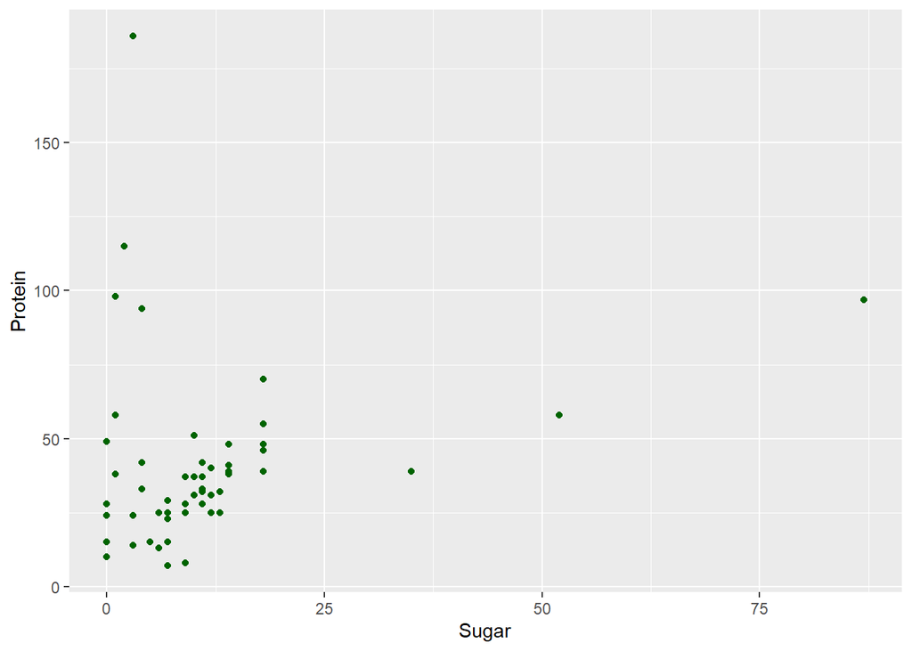

```r
fastfood %>%
  filter(str_detect(restaurant, "Mcdonalds"))%>%
  ggplot(aes(sugar, protein)) +
  geom_point(colour = "dark green") +
  labs(x = "Sugar", y = "Protein")
```

### Changing variable type

Identifying variable which should be factors and transforming their type into a factor variable (here “restaurant”)

```r
class(fastfood$restaurant)
```

```
## [1] "character"
```

```r
fastfood$restaurant <- as_factor(fastfood$restaurant)

class(fastfood$restaurant)
```

```
## [1] "factor"
```

### Calories in fastfood

Creating new variable “calories_type” using cut_number function and saving it as a new dataset “Calories_in_fastfood”

```r
Calories_in_fastfood <- fastfood %>%
  mutate(calories_type = cut_number(calories, n=3, labels = c("low", "med", "high"))) %>%
  arrange(desc(calories_type))

kable (Calories_in_fastfood)
```

| X | restaurant | item | calories | cal_fat | total_fat | sat_fat | trans_fat | cholesterol | sodium | total_carb | fiber | sugar | protein | vit_a | vit_c | calcium | heavy_food | cholesterol_sodium | calories_type |
| --- | --- | --- | --- | --- | --- | --- | --- | --- | --- | --- | --- | --- | --- | --- | --- | --- | --- | --- | --- |
| 2 | Mcdonalds | Single Bacon Smokehouse Burger | 840 | 410 | 45 | 17.0 | 1.5 | 130 | 1580 | 62 | 2 | 18 | 46 | 6 | 20 | 20 | heavy | 1710 | high |
| 3 | Mcdonalds | Double Bacon Smokehouse Burger | 1130 | 600 | 67 | 27.0 | 3.0 | 220 | 1920 | 63 | 3 | 18 | 70 | 10 | 20 | 50 | heavy | 2140 | high |
| 4 | Mcdonalds | Grilled Bacon Smokehouse Chicken Sandwich | 750 | 280 | 31 | 10.0 | 0.5 | 155 | 1940 | 62 | 2 | 18 | 55 | 6 | 25 | 20 | heavy | 2095 | high |
| 5 | Mcdonalds | Crispy Bacon Smokehouse Chicken Sandwich | 920 | 410 | 45 | 12.0 | 0.5 | 120 | 1980 | 81 | 4 | 18 | 46 | 6 | 20 | 20 | heavy | 2100 | high |
| 10 | Mcdonalds | Double Quarter PounderÂ® with Cheese | 770 | 400 | 45 | 21.0 | 2.5 | 175 | 1290 | 42 | 3 | 10 | 51 | 20 | 6 | 20 | heavy | 1465 | high |
| 12 | Mcdonalds | Garlic White Cheddar Burger | 620 | 300 | 34 | 13.0 | 1.5 | 95 | 790 | 48 | 3 | 11 | 32 | 10 | 10 | 35 | heavy | 885 | high |
| 14 | Mcdonalds | Crispy Garlic White Cheddar Chicken Sandwich | 700 | 300 | 34 | 9.0 | 0.0 | 85 | 1190 | 67 | 5 | 11 | 33 | 10 | 15 | 35 | heavy | 1275 | high |
| 17 | Mcdonalds | Maple Bacon Dijon 1/4 lb Burger | 640 | 330 | 36 | 14.0 | 1.5 | 110 | 1260 | 40 | 3 | 10 | 37 | 6 | 15 | 15 | heavy | 1370 | high |
| 19 | Mcdonalds | Crispy Maple Bacon Dijon Chicken Sandwich | 740 | 310 | 35 | 9.0 | 0.5 | 95 | 1780 | 69 | 5 | 14 | 39 | 4 | 20 | 290 | heavy | 1875 | high |
| 25 | Mcdonalds | Crispy Pico Guacamole Chicken Sandwich | 680 | 280 | 32 | 7.0 | 0.0 | 80 | 1430 | 69 | 6 | 12 | 31 | 8 | 15 | 30 | heavy | 1510 | high |
| 29 | Mcdonalds | Signature Sriracha Burger | 670 | 320 | 35 | 12.0 | 1.5 | 95 | 1010 | 56 | 4 | 13 | 32 | 20 | 15 | 30 | heavy | 1105 | high |
| 31 | Mcdonalds | Crispy Signature Sriracha Chicken Sandwich | 730 | 300 | 33 | 7.0 | 0.0 | 80 | 1430 | 75 | 5 | 13 | 32 | 20 | 20 | 30 | heavy | 1510 | high |
| 32 | Mcdonalds | Sweet BBQ Bacon 1/4 lb Burger | 690 | 340 | 37 | 14.0 | 1.5 | 110 | 1310 | 51 | 3 | 14 | 38 | 6 | 15 | 15 | heavy | 1420 | high |
| 33 | Mcdonalds | Grilled Sweet BBQ Bacon Chicken Sandwich | 630 | 200 | 22 | 7.0 | 0.0 | 135 | 1930 | 61 | 4 | 18 | 48 | 4 | 30 | 25 | heavy | 2065 | high |
| 34 | Mcdonalds | Crispy Sweet BBQ Bacon Chicken Sandwich | 800 | 320 | 36 | 9.0 | 0.5 | 95 | 1820 | 80 | 5 | 18 | 39 | 4 | 20 | 30 | heavy | 1915 | high |
| 37 | Mcdonalds | 6 piece Buttermilk Crispy Chicken Tenders | 760 | 390 | 44 | 8.0 | 0.5 | 145 | 1890 | 32 | 1 | 1 | 58 | 0 | 0 | 2 | heavy | 2035 | high |
| 38 | Mcdonalds | 10 piece Buttermilk Crispy Chicken Tenders | 1210 | 630 | 70 | 12.0 | 1.0 | 240 | 3230 | 52 | 1 | 4 | 94 | 0 | 0 | 4 | heavy | 3470 | high |
| 39 | Mcdonalds | 12 piece Buttermilk Crispy Chicken Tenders | 1510 | 790 | 88 | 15.0 | 1.0 | 295 | 3770 | 64 | 1 | 2 | 115 | 0 | 2 | 6 | heavy | 4065 | high |
| 40 | Mcdonalds | 20 piece Buttermilk Crispy Chicken Tenders | 2430 | 1270 | 141 | 24.0 | 2.0 | 475 | 6080 | 103 | 2 | 3 | 186 | 0 | 2 | 8 | heavy | 6555 | high |
| 44 | Mcdonalds | 20 Piece Chicken McNuggets | 890 | 480 | 53 | 9.0 | 0.0 | 145 | 1680 | 53 | 4 | 0 | 49 | 0 | 8 | 4 | heavy | 1825 | high |
| 45 | Mcdonalds | 40 piece Chicken McNuggets | 1770 | 960 | 107 | 18.0 | 0.5 | 295 | 3370 | 105 | 7 | 1 | 98 | 0 | 15 | 6 | heavy | 3665 | high |
| 46 | Mcdonalds | 4 piece Sweet N’ Spicy Honey BBQ Glazed Tenders | 640 | 240 | 27 | 4.0 | 0.0 | 105 | 1780 | 63 | 2 | 35 | 39 | 4 | 15 | 4 | heavy | 1885 | high |
| 47 | Mcdonalds | 6 piece Sweet N’ Spicy Honey BBQ Glazed Tenders | 960 | 360 | 40 | 6.0 | 0.0 | 160 | 2670 | 94 | 3 | 52 | 58 | 4 | 25 | 8 | heavy | 2830 | high |
| 48 | Mcdonalds | 10 piece Sweet N’ Spicy Honey BBQ Glazed Tenders | 1600 | 600 | 66 | 10.0 | 0.0 | 265 | 4450 | 156 | 5 | 87 | 97 | 8 | 40 | 10 | heavy | 4715 | high |
| 70 | Chick Fil-A | 30 piece Chicken Nuggets | 970 | 414 | 46 | 2.5 | 0.0 | 285 | 3660 | 35 | 4 | 1 | 103 | NA | 20 | 10 | heavy | 3945 | high |
| 83 | Chick Fil-A | Chicken Enchiladas Meal Kit | 860 | 423 | 47 | 16.0 | 1.0 | 100 | 2520 | 70 | NA | 8 | 39 | NA | NA | NA | heavy | 2620 | high |
| 84 | Chick Fil-A | Chicken Parmesan Meal Kit | 720 | 279 | 31 | 15.0 | 0.0 | 120 | 1780 | 65 | NA | 7 | 48 | NA | NA | NA | heavy | 1900 | high |
| 85 | Sonic | Hatch Green Chile Cheeseburger | 710 | 380 | 43 | 17.0 | 2.0 | 120 | 1120 | 44 | 2 | 7 | 35 | 10 | 25 | 30 | heavy | 1240 | high |
| 86 | Sonic | Jalapeno Burger | 640 | 330 | 37 | 14.0 | 2.0 | 100 | 930 | 42 | 2 | 6 | 31 | 4 | 2 | 20 | heavy | 1030 | high |
| 92 | Sonic | Sonic Bacon Cheeseburger (w/mayo) | 870 | 530 | 59 | 20.0 | 2.0 | 140 | 1350 | 45 | 2 | 7 | 39 | 10 | 8 | 30 | heavy | 1490 | high |

[output cut: 485 more lines]

### “Calories_type” in food items

Graph showing the distribution of “calories_type” in food items for each type of restaurant.

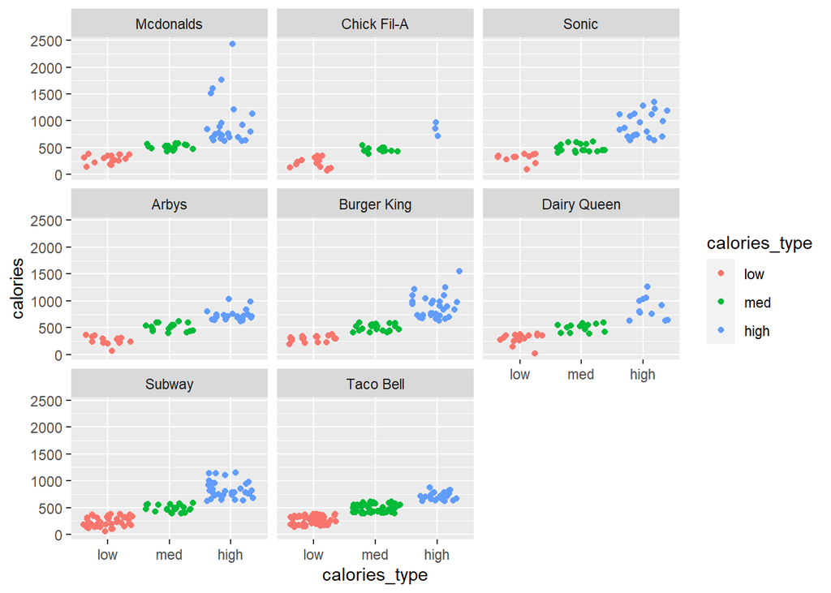

```r
ggplot(Calories_in_fastfood, aes(calories_type, calories, color = calories_type )) +
  geom_jitter() +
  facet_wrap( ~ restaurant)
```

### Calculating trans_fat_percent

Displaying first 10 rows with trans fat percentage

```r
fastfood <- fastfood %>%
  mutate(trans_fat_percent = (trans_fat/total_fat)*100)

kable (fastfood [1:10,])
```

| X | restaurant | item | calories | cal_fat | total_fat | sat_fat | trans_fat | cholesterol | sodium | total_carb | fiber | sugar | protein | vit_a | vit_c | calcium | heavy_food | cholesterol_sodium | trans_fat_percent |
| --- | --- | --- | --- | --- | --- | --- | --- | --- | --- | --- | --- | --- | --- | --- | --- | --- | --- | --- | --- |
| 1 | Mcdonalds | Artisan Grilled Chicken Sandwich | 380 | 60 | 7 | 2 | 0.0 | 95 | 1110 | 44 | 3 | 11 | 37 | 4 | 20 | 20 | average | 1205 | 0.000000 |
| 2 | Mcdonalds | Single Bacon Smokehouse Burger | 840 | 410 | 45 | 17 | 1.5 | 130 | 1580 | 62 | 2 | 18 | 46 | 6 | 20 | 20 | heavy | 1710 | 3.333333 |
| 3 | Mcdonalds | Double Bacon Smokehouse Burger | 1130 | 600 | 67 | 27 | 3.0 | 220 | 1920 | 63 | 3 | 18 | 70 | 10 | 20 | 50 | heavy | 2140 | 4.477612 |
| 4 | Mcdonalds | Grilled Bacon Smokehouse Chicken Sandwich | 750 | 280 | 31 | 10 | 0.5 | 155 | 1940 | 62 | 2 | 18 | 55 | 6 | 25 | 20 | heavy | 2095 | 1.612903 |
| 5 | Mcdonalds | Crispy Bacon Smokehouse Chicken Sandwich | 920 | 410 | 45 | 12 | 0.5 | 120 | 1980 | 81 | 4 | 18 | 46 | 6 | 20 | 20 | heavy | 2100 | 1.111111 |
| 6 | Mcdonalds | Big Mac | 540 | 250 | 28 | 10 | 1.0 | 80 | 950 | 46 | 3 | 9 | 25 | 10 | 2 | 15 | heavy | 1030 | 3.571429 |
| 7 | Mcdonalds | Cheeseburger | 300 | 100 | 12 | 5 | 0.5 | 40 | 680 | 33 | 2 | 7 | 15 | 10 | 2 | 10 | average | 720 | 4.166667 |
| 8 | Mcdonalds | Classic Chicken Sandwich | 510 | 210 | 24 | 4 | 0.0 | 65 | 1040 | 49 | 3 | 6 | 25 | 0 | 4 | 2 | heavy | 1105 | 0.000000 |
| 9 | Mcdonalds | Double Cheeseburger | 430 | 190 | 21 | 11 | 1.0 | 85 | 1040 | 35 | 2 | 7 | 25 | 20 | 4 | 15 | average | 1125 | 4.761905 |
| 10 | Mcdonalds | Double Quarter PounderÂ® with Cheese | 770 | 400 | 45 | 21 | 2.5 | 175 | 1290 | 42 | 3 | 10 | 51 | 20 | 6 | 20 | heavy | 1465 | 5.555556 |

### Trans_fat in food items

Graph showing shows the distribution of trans_fat in food items for each type of restaurant

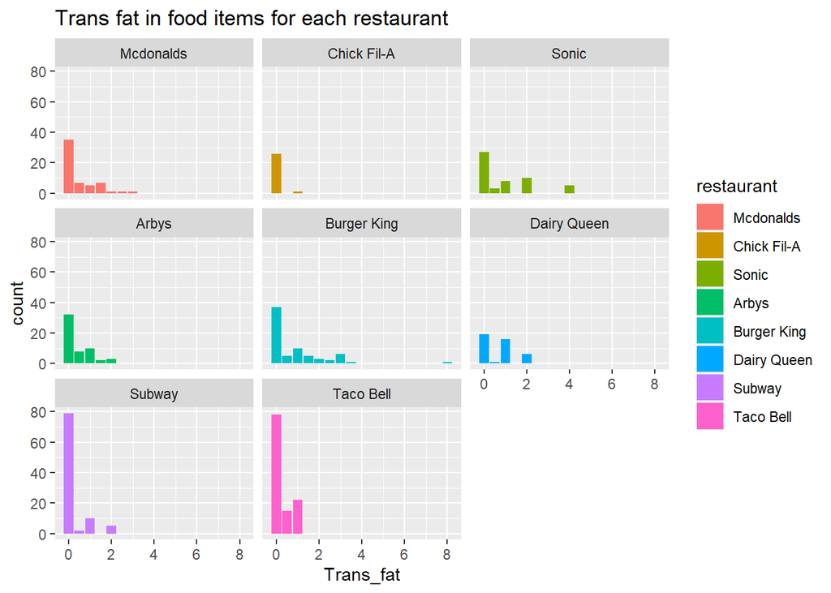

```r
ggplot(fastfood, aes(trans_fat, fill = restaurant)) +
  geom_bar() +
  facet_wrap( ~ restaurant) +
  labs(x = "Trans_fat", title = "Trans fat in food items for each restaurant")
```

### Average total fat

Calculating the average (mean) of “total_fat” for each type of restaurant

```r
fastfood %>%
  group_by(restaurant) %>%
  summarise(average_fat = mean(total_fat)) %>%
  ungroup()
```

```
## # A tibble: 8 x 2
##   restaurant  average_fat
##   <fct>             <dbl>
## 1 Mcdonalds          31.8
## 2 Chick Fil-A        16.1
## 3 Sonic              37.6
## 4 Arbys              27.0
## 5 Burger King        36.8
## 6 Dairy Queen        28.9
## 7 Subway             18.5
## 8 Taco Bell          20.9
```

### Comparing restaurants based on total fat

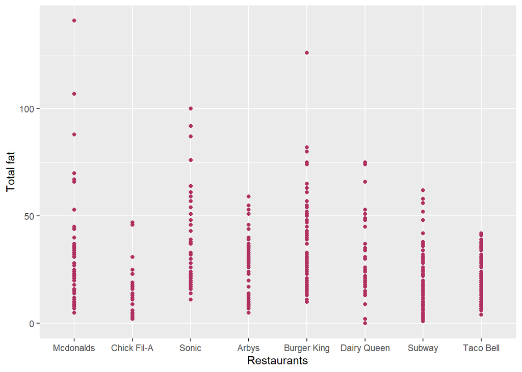

```r
ggplot(fastfood, aes(restaurant, total_fat)) + geom_point(color = "maroon") +
  labs(x = "Restaurants", y = "Total fat")
```